# CSC 478 - Hw1

```python
import numpy as np
import pandas as pd
%matplotlib inline
import matplotlib.pyplot as plt
import os

os.getcwd()
```

```
'C:\\Users\\cjcbg\\Desktop\\DSC 478'
```

### 1. Explore the general characteristics of the data as a whole: examine the means, standard deviations, and other statistics associated with the numerical attributes; also show the distributions of values associated with categorical attributes (for categorical attributes use Matplotlib library and/or plotting capabilities of Pandas to generate bar charts showing the distribution of categories for each attribute).

```python
bank = pd.read_csv('bank_data.csv',index_col = 0) # For ID
bank.head()
```

| id | age | income | children | gender | region | married | car | savings_acct | current_acct | mortgage | pep |
| --- | --- | --- | --- | --- | --- | --- | --- | --- | --- | --- | --- |
| ID12101 | 48 | 17546.0 | 1 | FEMALE | INNER_CITY | NO | NO | NO | NO | NO | YES |
| ID12102 | 40 | 30085.1 | 3 | MALE | TOWN | YES | YES | NO | YES | YES | NO |
| ID12103 | 51 | 16575.4 | 0 | FEMALE | INNER_CITY | YES | YES | YES | YES | NO | NO |
| ID12104 | 23 | 20375.4 | 3 | FEMALE | TOWN | YES | NO | NO | YES | NO | NO |
| ID12105 | 57 | 50576.3 | 0 | FEMALE | RURAL | YES | NO | YES | NO | NO | NO |

```python
bank.info()
```

```
<class 'pandas.core.frame.DataFrame'>
Index: 600 entries, ID12101 to ID12700
Data columns (total 11 columns):
age             600 non-null int64
income          600 non-null float64
children        600 non-null int64
gender          600 non-null object
region          600 non-null object
married         600 non-null object
car             600 non-null object
savings_acct    600 non-null object
current_acct    600 non-null object
mortgage        600 non-null object
pep             600 non-null object
dtypes: float64(1), int64(2), object(8)
memory usage: 56.2+ KB
```

Get the numeric data to show the relevant summary statisitics

```python
min_income = bank.income.min()
max_income = bank.income.max()
print(min_income,max_income)
```

```
5014.21 63130.1
```

```python
bank.describe()#numeric data
```

|  | age | income | children |
| --- | --- | --- | --- |
| count | 600.000000 | 600.000000 | 600.000000 |
| mean | 42.395000 | 27524.031217 | 1.011667 |
| std | 14.424947 | 12899.468246 | 1.056752 |
| min | 18.000000 | 5014.210000 | 0.000000 |
| 25% | 30.000000 | 17264.500000 | 0.000000 |
| 50% | 42.000000 | 24925.300000 | 1.000000 |
| 75% | 55.250000 | 36172.675000 | 2.000000 |
| max | 67.000000 | 63130.100000 | 3.000000 |

```python
bank.describe(include = "all")
```

|  | age | income | children | gender | region | married | car | savings_acct | current_acct | mortgage | pep |
| --- | --- | --- | --- | --- | --- | --- | --- | --- | --- | --- | --- |
| count | 600.000000 | 600.000000 | 600.000000 | 600 | 600 | 600 | 600 | 600 | 600 | 600 | 600 |
| unique | NaN | NaN | NaN | 2 | 4 | 2 | 2 | 2 | 2 | 2 | 2 |
| top | NaN | NaN | NaN | MALE | INNER_CITY | YES | NO | YES | YES | NO | NO |
| freq | NaN | NaN | NaN | 300 | 269 | 396 | 304 | 414 | 455 | 391 | 326 |
| mean | 42.395000 | 27524.031217 | 1.011667 | NaN | NaN | NaN | NaN | NaN | NaN | NaN | NaN |
| std | 14.424947 | 12899.468246 | 1.056752 | NaN | NaN | NaN | NaN | NaN | NaN | NaN | NaN |
| min | 18.000000 | 5014.210000 | 0.000000 | NaN | NaN | NaN | NaN | NaN | NaN | NaN | NaN |
| 25% | 30.000000 | 17264.500000 | 0.000000 | NaN | NaN | NaN | NaN | NaN | NaN | NaN | NaN |
| 50% | 42.000000 | 24925.300000 | 1.000000 | NaN | NaN | NaN | NaN | NaN | NaN | NaN | NaN |
| 75% | 55.250000 | 36172.675000 | 2.000000 | NaN | NaN | NaN | NaN | NaN | NaN | NaN | NaN |
| max | 67.000000 | 63130.100000 | 3.000000 | NaN | NaN | NaN | NaN | NaN | NaN | NaN | NaN |

```python
bank_categorical = bank.iloc[:,3:12]
bank_categorical.head()
```

| id | gender | region | married | car | savings_acct | current_acct | mortgage | pep |
| --- | --- | --- | --- | --- | --- | --- | --- | --- |
| ID12101 | FEMALE | INNER_CITY | NO | NO | NO | NO | NO | YES |
| ID12102 | MALE | TOWN | YES | YES | NO | YES | YES | NO |
| ID12103 | FEMALE | INNER_CITY | YES | YES | YES | YES | NO | NO |
| ID12104 | FEMALE | TOWN | YES | NO | NO | YES | NO | NO |
| ID12105 | FEMALE | RURAL | YES | NO | YES | NO | NO | NO |

```
array([[<matplotlib.axes._subplots.AxesSubplot object at 0x0000018D9CFC9E08>,
      dtype=object)
```

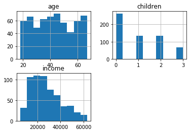

```python
bank.hist() #distribution of numeric data
```

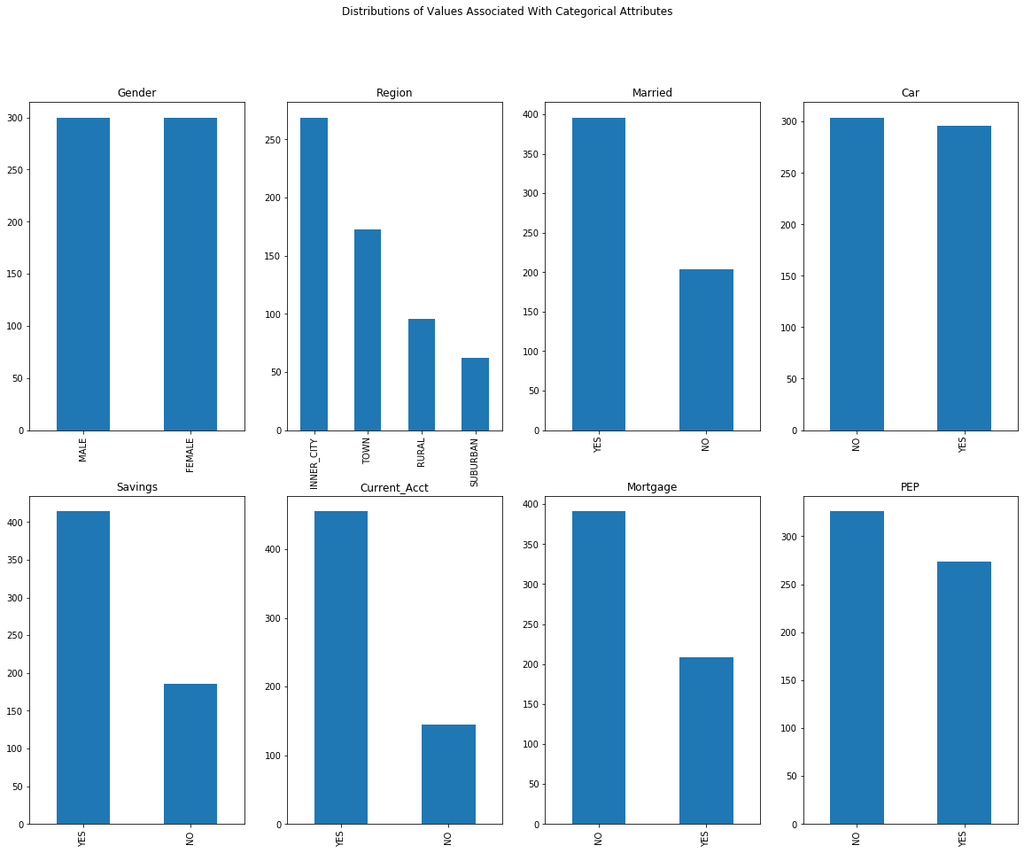

```python
f,axes = plt.subplots(2,4, figsize =(20,15)) #distribution of categorical data
f.suptitle('Distributions of Values Associated With Categorical Attributes')

ax1 = bank_categorical.gender.value_counts().plot(kind = 'bar',ax = axes[0,0],title = 'Gender')
ax2 = bank_categorical.region.value_counts().plot(kind = 'bar',ax = axes[0,1],title = 'Region')
ax3 = bank_categorical.married.value_counts().plot(kind = 'bar',ax = axes[0,2], title = 'Married')
ax4 = bank_categorical.car.value_counts().plot(kind = 'bar',ax = axes[0,3],title = 'Car')
ax5 = bank_categorical.savings_acct.value_counts().plot(kind = 'bar',ax = axes[1,0], title = 'Savings')
ax6 = bank_categorical.current_acct.value_counts().plot(kind = 'bar',ax = axes[1,1], title = 'Current_Acct')
ax7 = bank_categorical.mortgage.value_counts().plot(kind = 'bar',ax = axes[1,2],title = 'Mortgage')
ax8 =bank_categorical.pep.value_counts().plot(kind = 'bar',ax = axes[1,3],title = 'PEP')
```

### 2. Suppose that the hypothetical bank is particularly interested in customers who buy the PEP (Personal Equity Plan) product. Compare and contrast the subsets of customers who buy and don't buy the PEP. Compute summaries (as in part 1) of the selected data with respect to all other attributes (you do not need to plot distributions). Can you observe any significant differences between these segments of customers? Discuss your observations.

```python
pep_group = bank.groupby("pep").describe()
pep_group
```

| pep | age count | age mean | age std | age min | age 25% | age 50% | age 75% | age max | income count | income mean | income ... | income 75% | income max | children count | children mean | children std | children min | children 25% | children 50% | children 75% | children max |
| --- | --- | --- | --- | --- | --- | --- | --- | --- | --- | --- | --- | --- | --- | --- | --- | --- | --- | --- | --- | --- | --- |
| NO | 326.0 | 40.098160 | 14.123506 | 18.0 | 27.0 | 40.0 | 51.0 | 67.0 | 326.0 | 24900.953374 | ... | 31210.90 | 61554.6 | 326.0 | 1.067485 | 1.195524 | 0.0 | 0.0 | 0.0 | 2.0 | 3.0 |
| YES | 274.0 | 45.127737 | 14.327991 | 18.0 | 34.0 | 45.0 | 58.0 | 67.0 | 274.0 | 30644.919453 | ... | 38458.35 | 63130.1 | 274.0 | 0.945255 | 0.860571 | 0.0 | 0.0 | 1.0 | 1.0 | 3.0 |

2 rows × 24 columns

The above shows PEP against the numeric data in the dataframe (age,income, and children). From the above, we can see that the mean age of people who purchase a PEP plan is about 5 years higher than those who do not (45 v. 40). We can also see that the mean income is nearly $6,000 higher for those who purchase a PEP plan. People who purchase the PEP plan also have slightly less children on average. The overall counr of people who do not have a PEP plan is greater than those who do have a PEP plan.

```python
ct1 = pd.crosstab(bank_categorical.gender,bank_categorical.pep,margins = False)
ct2 = pd.crosstab(bank_categorical.region,bank_categorical.pep,margins = False)
ct3 = pd.crosstab(bank_categorical.married,bank_categorical.pep,margins = False)
ct4 = pd.crosstab(bank_categorical.car,bank_categorical.pep,margins = False)
ct5 = pd.crosstab(bank_categorical.savings_acct,bank_categorical.pep,margins = False)
ct6 = pd.crosstab(bank_categorical.current_acct,bank_categorical.pep,margins = False)
ct7 = pd.crosstab(bank_categorical.mortgage,bank_categorical.pep,margins = False)

print(ct1)
print('\n',ct2)
print('\n',ct3)
print('\n',ct4)
print('\n',ct5)
print('\n',ct6)
print('\n',ct7)
```

```
pep      NO  YES
gender
FEMALE  170  130
MALE    156  144

 pep          NO  YES
region
INNER_CITY  146  123
RURAL        50   46
SUBURBAN     28   34
TOWN        102   71

 pep       NO  YES
married
NO        84  120
YES      242  154

 pep   NO  YES
car
NO   168  136
YES  158  138

 pep            NO  YES
savings_acct
NO             91   95
YES           235  179

 pep            NO  YES
current_acct
NO             82   63
YES           244  211

 pep        NO  YES
mortgage
NO        209  182
YES       117   92
```

Looking at the PEP within the categorical data, we can observe the below in order of the crosstabs:

1. Slightly more Males have PEP than Females
2. We can see the proportion of with the highest amount PEP plans per region is actually the suburbs (judging by %'s, not raw numbers)
3. People who are not married have a higher proportion of having the PEP plan
4. We see that the people who have car and people who don't nearly have the same proportion of PEP plans
5. People who don't have a saving plan have a greater of proportion of having the PEP
6. The proportion of people who have a PEP plans with a current account vs. those who don't have a current account is nearly the same
7. People without a mortgage have a higher proportion of having the PEP. A lot of the banks customers live in inter city, so this is not suprising.

### 3. Use z-score normalization to standardize the values of the income attribute. [Do not change the original income attribute or add the normalized income to the table.]

```python
income_z = (bank.income - bank.income.mean())/bank.income.std()
income_z.head()
```

```
id
ID12101   -0.773523
ID12102    0.198541
ID12103   -0.848766
ID12104   -0.554180
ID12105    1.787071
Name: income, dtype: float64
```

### 4. Discretize the age attribute into 3 categories (corresponding to "young", "mid-age", and "old"). [Do not change the original age attribute or add the discretized age to the table.]

```python
bank.age.describe()
```

```
count    600.000000
mean      42.395000
std       14.424947
min       18.000000
25%       30.000000
50%       42.000000
75%       55.250000
max       67.000000
Name: age, dtype: float64
```

```python
age_bins = pd.qcut(bank.age,[0,.33,.66,1],labels = ["young","mid-age","old"])
age_bins.head()
```

```
id
ID12101    mid-age
ID12102    mid-age
ID12103        old
ID12104      young
ID12105        old
Name: age, dtype: category
Categories (3, object): [young < mid-age < old]
```

### 5. Use Min-Max Normalization to transform the values of all numeric attributes (income, age, children) in the original table onto the range 0.0-1.0.

```python
#min max norm numerical data
bank["income_norm"] = (bank.income-bank.income.min())/(bank.income.max()-bank.income.min())
bank["age_norm"] = (bank.age-bank.age.min())/(bank.age.max()-bank.age.min())
bank["children_norm"] = (bank.children-bank.children.min())/(bank.children.max()-bank.children.min())

bank.head()
```

| id | age | income | children | gender | region | married | car | savings_acct | current_acct | mortgage | pep | income_norm | age_norm | children_norm |
| --- | --- | --- | --- | --- | --- | --- | --- | --- | --- | --- | --- | --- | --- | --- |
| ID12101 | 48 | 17546.0 | 1 | FEMALE | INNER_CITY | NO | NO | NO | NO | NO | YES | 0.215634 | 0.612245 | 0.333333 |
| ID12102 | 40 | 30085.1 | 3 | MALE | TOWN | YES | YES | NO | YES | YES | NO | 0.431395 | 0.448980 | 1.000000 |
| ID12103 | 51 | 16575.4 | 0 | FEMALE | INNER_CITY | YES | YES | YES | YES | NO | NO | 0.198933 | 0.673469 | 0.000000 |
| ID12104 | 23 | 20375.4 | 3 | FEMALE | TOWN | YES | NO | NO | YES | NO | NO | 0.264320 | 0.102041 | 1.000000 |
| ID12105 | 57 | 50576.3 | 0 | FEMALE | RURAL | YES | NO | YES | NO | NO | NO | 0.783987 | 0.795918 | 0.000000 |

### 6. Convert the table (after normalization in part 5) into the standard spreadsheet format. Note that this requires converting each categorical attribute into multiple binary ("dummy") attributes (one for each values of the categorical attribute) and assigning binary values corresponding to the presence or not presence of the attribute value in the original record). The numeric attributes should remain unchanged. Save this new table into a file called bank_numeric.csv and submit it along with your assignment.

```python
#first creating numeric data frame, with just norm vals
bank_numeric = pd.get_dummies(bank.iloc[:,3:14],prefix = ['gender','region','married','car','savings_acct','current_acct','mortgage','pep'])
bank_numeric.head()
```

| id | income_norm | age_norm | children_norm | gender_FEMALE | gender_MALE | region_INNER_CITY | region_RURAL | region_SUBURBAN | region_TOWN | married_NO | ... | car_NO | car_YES | savings_acct_NO | savings_acct_YES | current_acct_NO | current_acct_YES | mortgage_NO | mortgage_YES | pep_NO | pep_YES |
| --- | --- | --- | --- | --- | --- | --- | --- | --- | --- | --- | --- | --- | --- | --- | --- | --- | --- | --- | --- | --- | --- |
| ID12101 | 0.215634 | 0.612245 | 0.333333 | 1 | 0 | 1 | 0 | 0 | 0 | 1 | ... | 1 | 0 | 1 | 0 | 1 | 0 | 1 | 0 | 0 | 1 |
| ID12102 | 0.431395 | 0.448980 | 1.000000 | 0 | 1 | 0 | 0 | 0 | 1 | 0 | ... | 0 | 1 | 1 | 0 | 0 | 1 | 0 | 1 | 1 | 0 |
| ID12103 | 0.198933 | 0.673469 | 0.000000 | 1 | 0 | 1 | 0 | 0 | 0 | 0 | ... | 0 | 1 | 0 | 1 | 0 | 1 | 1 | 0 | 1 | 0 |
| ID12104 | 0.264320 | 0.102041 | 1.000000 | 1 | 0 | 0 | 0 | 0 | 1 | 0 | ... | 1 | 0 | 1 | 0 | 0 | 1 | 1 | 0 | 1 | 0 |
| ID12105 | 0.783987 | 0.795918 | 0.000000 | 1 | 0 | 0 | 1 | 0 | 0 | 0 | ... | 1 | 0 | 0 | 1 | 1 | 0 | 1 | 0 | 1 | 0 |

5 rows × 21 columns

```python
bank_numeric.to_csv('bank_numeric.csv')
bank_numeric.head()
```

| id | income_norm | age_norm | children_norm | gender_FEMALE | gender_MALE | region_INNER_CITY | region_RURAL | region_SUBURBAN | region_TOWN | married_NO | ... | car_NO | car_YES | savings_acct_NO | savings_acct_YES | current_acct_NO | current_acct_YES | mortgage_NO | mortgage_YES | pep_NO | pep_YES |
| --- | --- | --- | --- | --- | --- | --- | --- | --- | --- | --- | --- | --- | --- | --- | --- | --- | --- | --- | --- | --- | --- |
| ID12101 | 0.215634 | 0.612245 | 0.333333 | 1 | 0 | 1 | 0 | 0 | 0 | 1 | ... | 1 | 0 | 1 | 0 | 1 | 0 | 1 | 0 | 0 | 1 |
| ID12102 | 0.431395 | 0.448980 | 1.000000 | 0 | 1 | 0 | 0 | 0 | 1 | 0 | ... | 0 | 1 | 1 | 0 | 0 | 1 | 0 | 1 | 1 | 0 |
| ID12103 | 0.198933 | 0.673469 | 0.000000 | 1 | 0 | 1 | 0 | 0 | 0 | 0 | ... | 0 | 1 | 0 | 1 | 0 | 1 | 1 | 0 | 1 | 0 |
| ID12104 | 0.264320 | 0.102041 | 1.000000 | 1 | 0 | 0 | 0 | 0 | 1 | 0 | ... | 1 | 0 | 1 | 0 | 0 | 1 | 1 | 0 | 1 | 0 |
| ID12105 | 0.783987 | 0.795918 | 0.000000 | 1 | 0 | 0 | 1 | 0 | 0 | 0 | ... | 1 | 0 | 0 | 1 | 1 | 0 | 1 | 0 | 1 | 0 |

5 rows × 21 columns

```python
bank_numeric.describe()
```

|  | income_norm | age_norm | children_norm | gender_FEMALE | gender_MALE | region_INNER_CITY | region_RURAL | region_SUBURBAN | region_TOWN | married_NO | ... | car_NO | car_YES | savings_acct_NO | savings_acct_YES | current_acct_NO | current_acct_YES | mortgage_NO | mortgage_YES | pep_NO | pep_YES |
| --- | --- | --- | --- | --- | --- | --- | --- | --- | --- | --- | --- | --- | --- | --- | --- | --- | --- | --- | --- | --- | --- |
| count | 600.000000 | 600.000000 | 600.000000 | 600.000000 | 600.000000 | 600.000000 | 600.000000 | 600.000000 | 600.000000 | 600.000000 | ... | 600.000000 | 600.000000 | 600.000000 | 600.000000 | 600.000000 | 600.000000 | 600.000000 | 600.000000 | 600.000000 | 600.000000 |
| mean | 0.387326 | 0.497857 | 0.337222 | 0.500000 | 0.500000 | 0.448333 | 0.160000 | 0.103333 | 0.288333 | 0.340000 | ... | 0.506667 | 0.493333 | 0.310000 | 0.690000 | 0.241667 | 0.758333 | 0.651667 | 0.348333 | 0.543333 | 0.456667 |
| std | 0.221961 | 0.294387 | 0.352251 | 0.500417 | 0.500417 | 0.497738 | 0.366912 | 0.304648 | 0.453365 | 0.474104 | ... | 0.500373 | 0.500373 | 0.462879 | 0.462879 | 0.428451 | 0.428451 | 0.476840 | 0.476840 | 0.498534 | 0.498534 |
| min | 0.000000 | 0.000000 | 0.000000 | 0.000000 | 0.000000 | 0.000000 | 0.000000 | 0.000000 | 0.000000 | 0.000000 | ... | 0.000000 | 0.000000 | 0.000000 | 0.000000 | 0.000000 | 0.000000 | 0.000000 | 0.000000 | 0.000000 | 0.000000 |
| 25% | 0.210791 | 0.244898 | 0.000000 | 0.000000 | 0.000000 | 0.000000 | 0.000000 | 0.000000 | 0.000000 | 0.000000 | ... | 0.000000 | 0.000000 | 0.000000 | 0.000000 | 0.000000 | 1.000000 | 0.000000 | 0.000000 | 0.000000 | 0.000000 |
| 50% | 0.342610 | 0.489796 | 0.333333 | 0.500000 | 0.500000 | 0.000000 | 0.000000 | 0.000000 | 0.000000 | 0.000000 | ... | 1.000000 | 0.000000 | 0.000000 | 1.000000 | 0.000000 | 1.000000 | 1.000000 | 0.000000 | 1.000000 | 0.000000 |
| 75% | 0.536144 | 0.760204 | 0.666667 | 1.000000 | 1.000000 | 1.000000 | 0.000000 | 0.000000 | 1.000000 | 1.000000 | ... | 1.000000 | 1.000000 | 1.000000 | 1.000000 | 0.000000 | 1.000000 | 1.000000 | 1.000000 | 1.000000 | 1.000000 |
| max | 1.000000 | 1.000000 | 1.000000 | 1.000000 | 1.000000 | 1.000000 | 1.000000 | 1.000000 | 1.000000 | 1.000000 | ... | 1.000000 | 1.000000 | 1.000000 | 1.000000 | 1.000000 | 1.000000 | 1.000000 | 1.000000 | 1.000000 | 1.000000 |

8 rows × 21 columns

### 7. Using the numeric data set with the dummy variables (of the previous part), perform basic correlation analysis among the attributes. Discuss your results by indicating any significant positive or negative correlations among pairs of attributes. You need to construct a complete Correlation Matrix. Be sure to first remove the Customer ID column before creating the correlation matrix. [Hint: you can create the correlation matrix by using the corr() function in Pandas or corrcoef function in NumPy].

```python
corr_matrix = bank_numeric.corr()
corr_matrix
```

|  | income_norm | age_norm | children_norm | gender_FEMALE | gender_MALE | region_INNER_CITY | region_RURAL | region_SUBURBAN | region_TOWN | married_NO | ... | car_NO | car_YES | savings_acct_NO | savings_acct_YES | current_acct_NO | current_acct_YES | mortgage_NO | mortgage_YES | pep_NO | pep_YES |
| --- | --- | --- | --- | --- | --- | --- | --- | --- | --- | --- | --- | --- | --- | --- | --- | --- | --- | --- | --- | --- | --- |
| income_norm | 1.000000 | 0.752726 | 0.036761 | 0.023845 | -0.023845 | -0.047564 | 0.084776 | 0.029824 | -0.036431 | 0.008386 | ... | -0.081556 | 0.081556 | -0.266164 | 0.266164 | -0.031616 | 0.031616 | 0.014662 | -0.014662 | -0.221991 | 0.221991 |
| age_norm | 0.752726 | 1.000000 | 0.023572 | 0.090081 | -0.090081 | -0.025171 | 0.018635 | 0.031345 | -0.008510 | -0.010394 | ... | -0.077733 | 0.077733 | -0.184389 | 0.184389 | 0.035312 | -0.035312 | 0.016154 | -0.016154 | -0.173825 | 0.173825 |
| children_norm | 0.036761 | 0.023572 | 1.000000 | 0.014206 | -0.014206 | -0.051222 | 0.089902 | -0.014122 | -0.007033 | 0.048716 | ... | -0.036455 | 0.036455 | -0.041536 | 0.041536 | -0.006238 | 0.006238 | 0.074339 | -0.074339 | 0.057663 | -0.057663 |
| gender_FEMALE | 0.023845 | 0.090081 | 0.014206 | 1.000000 | -1.000000 | -0.023459 | -0.009092 | -0.010951 | 0.040472 | 0.021110 | ... | 0.006667 | -0.006667 | 0.007207 | -0.007207 | -0.019466 | 0.019466 | 0.066465 | -0.066465 | 0.046843 | -0.046843 |
| gender_MALE | -0.023845 | -0.090081 | -0.014206 | -1.000000 | 1.000000 | 0.023459 | 0.009092 | 0.010951 | -0.040472 | -0.021110 | ... | -0.006667 | 0.006667 | -0.007207 | 0.007207 | 0.019466 | -0.019466 | -0.066465 | 0.066465 | -0.046843 | 0.046843 |
| region_INNER_CITY | -0.047564 | -0.025171 | -0.051222 | -0.023459 | 0.023459 | 1.000000 | -0.393444 | -0.306032 | -0.573814 | -0.003254 | ... | 0.018143 | -0.018143 | 0.091373 | -0.091373 | -0.007894 | 0.007894 | -0.002098 | 0.002098 | -0.001054 | 0.001054 |
| region_RURAL | 0.084776 | 0.018635 | 0.089902 | -0.009092 | 0.009092 | -0.393444 | 1.000000 | -0.148158 | -0.277798 | 0.022649 | ... | -0.024006 | 0.024006 | -0.036960 | 0.036960 | 0.008496 | -0.008496 | 0.051908 | -0.051908 | -0.019714 | 0.019714 |
| region_SUBURBAN | 0.029824 | 0.031345 | -0.014122 | -0.010951 | 0.010951 | -0.306032 | -0.148158 | 1.000000 | -0.216080 | -0.012483 | ... | 0.061184 | -0.061184 | -0.002605 | 0.002605 | -0.038157 | 0.038157 | -0.004635 | 0.004635 | -0.062508 | 0.062508 |
| region_TOWN | -0.036431 | -0.008510 | -0.007033 | 0.040472 | -0.040472 | -0.573814 | -0.277798 | -0.216080 | 1.000000 | -0.006369 | ... | -0.041604 | 0.041604 | -0.068654 | 0.068654 | 0.027431 | -0.027431 | -0.036591 | 0.036591 | 0.059115 | -0.059115 |
| married_NO | 0.008386 | -0.010394 | 0.048716 | 0.021110 | -0.021110 | -0.003254 | 0.022649 | -0.012483 | -0.006369 | 1.000000 | ... | -0.009571 | 0.009571 | 0.028604 | -0.028604 | -0.059996 | 0.059996 | -0.021711 | 0.021711 | -0.189578 | 0.189578 |
| married_YES | -0.008386 | 0.010394 | -0.048716 | -0.021110 | 0.021110 | 0.003254 | -0.022649 | 0.012483 | 0.006369 | -1.000000 | ... | 0.009571 | -0.009571 | -0.028604 | 0.028604 | 0.059996 | -0.059996 | 0.021711 | -0.021711 | 0.189578 | -0.189578 |
| car_NO | -0.081556 | -0.077733 | -0.036455 | 0.006667 | -0.006667 | 0.018143 | -0.024006 | 0.061184 | -0.041604 | -0.009571 | ... | 1.000000 | -1.000000 | 0.034310 | -0.034310 | -0.034783 | 0.034783 | -0.007743 | 0.007743 | 0.018917 | -0.018917 |
| car_YES | 0.081556 | 0.077733 | 0.036455 | -0.006667 | 0.006667 | -0.018143 | 0.024006 | -0.061184 | 0.041604 | 0.009571 | ... | -1.000000 | 1.000000 | -0.034310 | 0.034310 | 0.034783 | -0.034783 | 0.007743 | -0.007743 | -0.018917 | 0.018917 |
| savings_acct_NO | -0.266164 | -0.184389 | -0.041536 | 0.007207 | -0.007207 | 0.091373 | -0.036960 | -0.002605 | -0.068654 | 0.028604 | ... | 0.034310 | -0.034310 | 1.000000 | -1.000000 | 0.042511 | -0.042511 | -0.001588 | 0.001588 | -0.072779 | 0.072779 |
| savings_acct_YES | 0.266164 | 0.184389 | 0.041536 | -0.007207 | 0.007207 | -0.091373 | 0.036960 | 0.002605 | 0.068654 | -0.028604 | ... | -0.034310 | 0.034310 | -1.000000 | 1.000000 | -0.042511 | 0.042511 | 0.001588 | -0.001588 | 0.072779 | -0.072779 |
| current_acct_NO | -0.031616 | 0.035312 | -0.006238 | -0.019466 | 0.019466 | -0.007894 | 0.008496 | -0.038157 | 0.027431 | -0.059996 | ... | -0.034783 | 0.034783 | 0.042511 | -0.042511 | 1.000000 | -1.000000 | -0.036704 | 0.036704 | 0.025141 | -0.025141 |
| current_acct_YES | 0.031616 | -0.035312 | 0.006238 | 0.019466 | -0.019466 | 0.007894 | -0.008496 | 0.038157 | -0.027431 | 0.059996 | ... | 0.034783 | -0.034783 | -0.042511 | 0.042511 | -1.000000 | 1.000000 | 0.036704 | -0.036704 | -0.025141 | 0.025141 |
| mortgage_NO | 0.014662 | 0.016154 | 0.074339 | 0.066465 | -0.066465 | -0.002098 | 0.051908 | -0.004635 | -0.036591 | -0.021711 | ... | -0.007743 | 0.007743 | -0.001588 | 0.001588 | -0.036704 | 0.036704 | 1.000000 | -1.000000 | -0.024182 | 0.024182 |
| mortgage_YES | -0.014662 | -0.016154 | -0.074339 | -0.066465 | 0.066465 | 0.002098 | -0.051908 | 0.004635 | 0.036591 | 0.021711 | ... | 0.007743 | -0.007743 | 0.001588 | -0.001588 | 0.036704 | -0.036704 | -1.000000 | 1.000000 | 0.024182 | -0.024182 |
| pep_NO | -0.221991 | -0.173825 | 0.057663 | 0.046843 | -0.046843 | -0.001054 | -0.019714 | -0.062508 | 0.059115 | -0.189578 | ... | 0.018917 | -0.018917 | -0.072779 | 0.072779 | 0.025141 | -0.025141 | -0.024182 | 0.024182 | 1.000000 | -1.000000 |
| pep_YES | 0.221991 | 0.173825 | -0.057663 | -0.046843 | 0.046843 | 0.001054 | 0.019714 | 0.062508 | -0.059115 | 0.189578 | ... | -0.018917 | 0.018917 | 0.072779 | -0.072779 | -0.025141 | 0.025141 | 0.024182 | -0.024182 | -1.000000 | 1.000000 |

21 rows × 21 columns

We can see the below from our correlation matrix:

1. Age and Income are correlated
2. It should be a given that every binary / categorical response will be negatively correlated with the opposite/ other response (ie. married_YES will be negatively correlated with married_NO)
3. There seems to be nearly no correlation with children and income as well as children and age.
4. The correlation of income and savings_acct_YES is maybe worth mentioning, depending on your threshold

### 8. Create a scatter plot of the (non-normalized) Income attribute relative to Age. Be sure that your plot contains appropriate labels for the axes. Do these variables seem correlated?

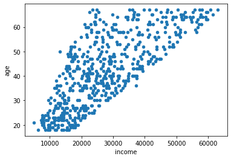

```python
bank.plot(x="income",y = "age", kind = "scatter")
```

The two variables seem correlated. This is confirmed when looking at the correlation matrix, as we can see that the correlation .75 between the two variables.

### 9. Create histograms for (non-normalized) Income (using 9 bins) and Age (using 15 bins).

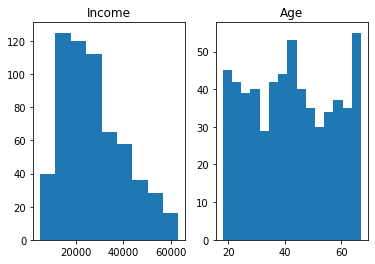

```python
fig,axi = plt.subplots(nrows=1,ncols=2)
ax0,ax1 = axi.flatten()
ax0.hist(bank.income,bins=9,histtype='bar')
ax0.set_title('Income')
ax1.hist(bank.age,bins = 15,histtype ='bar')
ax1.set_title('Age')
```

### 10. Perform a cross-tabulation of the region attribute with the pep attribute. This requires the aggregation of the occurrences of each pep value (yes or no) separately for each value of the region attribute. Show the results as a 4 by 2 (region x pep) table with entries representing the counts. [Hint: you can either use Numpy or use aggregations functions in Pandas such as groupby() and cross-tab().] Then, either using Matplotlib directly or the plot() function in Pandas create a bar chart graph to visualize of the relationships between these sets of variables. [Hint: This example of creating simple bar charts using Matplotlib may be useful.]

```python
ct2 # from question 2 analysis
```

| pep region | NO | YES |
| --- | --- | --- |
| INNER_CITY | 146 | 123 |
| RURAL | 50 | 46 |
| SUBURBAN | 28 | 34 |
| TOWN | 102 | 71 |

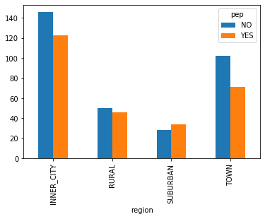

```python
plt.show(ct2.plot(kind = "bar"))
```

### 11. Now consider a modified version of the bank data that contains missing values (bank_data_missing_vals.csv).

### (a) Using Pandas determine all the attributes with missing values and the number of missing values for each such attribute.

### (b) Show all the instances in the data that contain a missing value.

### (c) Fill the missing values for all numeric attributes using the mean value for the attribute.

### (d) After filling in the missing numeric values, drop all rows where a categorical attribute contains a missing value.

### (e) Show that the final resulting table does not contain missing values.

```python
#displaying overview of bank_data_missing_vals
bank_missing = pd.read_csv('bank_data_missing_vals.csv',index_col = 0,na_values = ["?"]) # For ID
bank_missing.head()
```

| id | age | income | children | gender | region | married | car | savings_acct | current_acct | mortgage | pep |
| --- | --- | --- | --- | --- | --- | --- | --- | --- | --- | --- | --- |
| ID12101 | 48.0 | 17546.0 | 1 | FEMALE | INNER_CITY | NO | NO | NO | NO | NO | YES |
| ID12102 | 40.0 | 30085.1 | 3 | MALE | TOWN | YES | YES | NO | YES | YES | NO |
| ID12103 | 51.0 | 16575.4 | 0 | FEMALE | INNER_CITY | YES | YES | YES | YES | NO | NO |
| ID12104 | 23.0 | NaN | 3 | FEMALE | TOWN | YES | NO | NO | YES | NO | NO |
| ID12105 | 57.0 | 50576.3 | 0 | FEMALE | RURAL | YES | NO | YES | NO | NO | NO |

```python
#a T/F
bank_missing.isnull().any()
```

```
age              True
income           True
children        False
gender           True
region           True
married         False
car             False
savings_acct    False
current_acct    False
mortgage        False
pep             False
dtype: bool
```

```python
#b Number
bank_missing.isna().sum()
```

```
age             10
income          13
children         0
gender          10
region           9
married          0
car              0
savings_acct     0
current_acct     0
mortgage         0
pep              0
dtype: int64
```

```python
bank_missing.info() #another way to see nulls
```

```
<class 'pandas.core.frame.DataFrame'>
Index: 600 entries, ID12101 to ID12700
Data columns (total 11 columns):
age             590 non-null float64
income          587 non-null float64
children        600 non-null int64
gender          590 non-null object
region          591 non-null object
married         600 non-null object
car             600 non-null object
savings_acct    600 non-null object
current_acct    600 non-null object
mortgage        600 non-null object
pep             600 non-null object
dtypes: float64(2), int64(1), object(8)
memory usage: 56.2+ KB
```

```python
#b
bank_missing[bank_missing.isna().any(axis = 1)] #all instances
```

| id | age | income | children | gender | region | married | car | savings_acct | current_acct | mortgage | pep |
| --- | --- | --- | --- | --- | --- | --- | --- | --- | --- | --- | --- |
| ID12104 | 23.0 | NaN | 3 | FEMALE | TOWN | YES | NO | NO | YES | NO | NO |
| ID12107 | 22.0 | 8877.07 | 0 | MALE | NaN | NO | NO | NO | YES | NO | YES |
| ID12109 | 37.0 | NaN | 2 | FEMALE | SUBURBAN | YES | YES | NO | NO | NO | NO |
| ID12135 | 43.0 | NaN | 0 | MALE | SUBURBAN | NO | NO | YES | YES | NO | YES |
| ID12142 | 47.0 | 26952.60 | 0 | NaN | INNER_CITY | YES | YES | NO | YES | NO | NO |
| ID12162 | 65.0 | 36589.00 | 1 | FEMALE | NaN | NO | YES | NO | YES | NO | YES |
| ID12178 | 61.0 | 49456.70 | 1 | NaN | INNER_CITY | YES | YES | YES | YES | YES | YES |
| ID12182 | 30.0 | NaN | 3 | MALE | INNER_CITY | NO | NO | NO | YES | NO | NO |
| ID12189 | 30.0 | 15848.70 | 0 | MALE | NaN | YES | YES | YES | NO | YES | NO |
| ID12202 | NaN | 11604.40 | 2 | FEMALE | INNER_CITY | YES | YES | YES | YES | NO | NO |
| ID12242 | 47.0 | 22791.40 | 0 | NaN | INNER_CITY | YES | NO | NO | YES | NO | NO |
| ID12248 | 20.0 | 18860.30 | 2 | FEMALE | NaN | NO | NO | YES | YES | NO | NO |
| ID12283 | 65.0 | NaN | 0 | FEMALE | INNER_CITY | NO | YES | YES | YES | YES | NO |
| ID12285 | 38.0 | NaN | 0 | FEMALE | INNER_CITY | NO | YES | YES | NO | YES | NO |
| ID12293 | 64.0 | 49024.90 | 3 | NaN | RURAL | YES | NO | YES | YES | NO | YES |
| ID12351 | 65.0 | NaN | 0 | MALE | INNER_CITY | NO | NO | YES | YES | YES | NO |
| ID12380 | 40.0 | 36972.40 | 1 | MALE | NaN | YES | NO | NO | YES | YES | YES |
| ID12381 | 32.0 | 22327.80 | 1 | NaN | INNER_CITY | YES | NO | NO | NO | NO | YES |
| ID12411 | NaN | 30658.70 | 0 | MALE | TOWN | YES | NO | YES | YES | NO | NO |
| ID12454 | 48.0 | NaN | 1 | MALE | TOWN | NO | YES | YES | YES | NO | YES |
| ID12461 | NaN | 51620.80 | 2 | FEMALE | TOWN | NO | YES | YES | YES | NO | YES |
| ID12462 | 56.0 | 19918.90 | 3 | MALE | NaN | YES | NO | YES | YES | YES | NO |
| ID12484 | 40.0 | 34836.80 | 1 | NaN | TOWN | YES | YES | YES | YES | NO | YES |
| ID12487 | 49.0 | NaN | 0 | MALE | INNER_CITY | NO | NO | NO | YES | NO | NO |
| ID12527 | NaN | NaN | 3 | FEMALE | TOWN | YES | NO | YES | NO | NO | NO |
| ID12544 | NaN | 33302.80 | 0 | MALE | TOWN | NO | YES | NO | YES | YES | YES |
| ID12557 | 32.0 | 13267.60 | 0 | FEMALE | NaN | YES | YES | YES | YES | YES | NO |
| ID12562 | 64.0 | 24554.10 | 0 | NaN | SUBURBAN | YES | YES | YES | NO | YES | NO |
| ID12566 | 57.0 | NaN | 2 | FEMALE | TOWN | YES | YES | YES | YES | YES | NO |
| ID12568 | 34.0 | 12810.20 | 3 | FEMALE | NaN | NO | NO | YES | YES | NO | YES |
| ID12579 | NaN | 23337.20 | 2 | MALE | TOWN | YES | NO | YES | YES | YES | NO |
| ID12610 | NaN | 11215.30 | 2 | FEMALE | RURAL | YES | YES | YES | YES | NO | YES |
| ID12639 | NaN | 38784.00 | 0 | FEMALE | INNER_CITY | YES | NO | YES | YES | NO | NO |
| ID12649 | NaN | 20736.20 | 1 | MALE | RURAL | YES | YES | YES | YES | NO | YES |
| ID12650 | 58.0 | 52662.50 | 1 | NaN | TOWN | YES | YES | YES | YES | YES | YES |
| ID12670 | 49.0 | 17944.20 | 1 | MALE | NaN | NO | YES | YES | YES | YES | YES |
| ID12685 | 33.0 | NaN | 1 | NaN | TOWN | YES | NO | YES | YES | YES | YES |
| ID12692 | NaN | 31473.90 | 2 | FEMALE | INNER_CITY | NO | NO | YES | YES | YES | YES |
| ID12693 | 48.0 | 20268.00 | 0 | NaN | TOWN | YES | NO | YES | YES | NO | NO |
| ID12697 | 30.0 | NaN | 0 | FEMALE | INNER_CITY | YES | YES | YES | YES | NO | NO |

```python
#c
#fill age & income with mean
age_mean = bank_missing.age.mean()
bank_missing.age.fillna(age_mean,axis=0,inplace=True)

income_mean = bank_missing.income.mean()
bank_missing.income.fillna(income_mean,axis=0,inplace=True)

bank_missing.head()
```

| id | age | income | children | gender | region | married | car | savings_acct | current_acct | mortgage | pep |
| --- | --- | --- | --- | --- | --- | --- | --- | --- | --- | --- | --- |
| ID12101 | 48.0 | 17546.000000 | 1 | FEMALE | INNER_CITY | NO | NO | NO | NO | NO | YES |
| ID12102 | 40.0 | 30085.100000 | 3 | MALE | TOWN | YES | YES | NO | YES | YES | NO |
| ID12103 | 51.0 | 16575.400000 | 0 | FEMALE | INNER_CITY | YES | YES | YES | YES | NO | NO |
| ID12104 | 23.0 | 27475.594685 | 3 | FEMALE | TOWN | YES | NO | NO | YES | NO | NO |
| ID12105 | 57.0 | 50576.300000 | 0 | FEMALE | RURAL | YES | NO | YES | NO | NO | NO |

```python
#d
#drop gender and region na's
bank_missing.drop(bank_missing[bank_missing.gender.isnull()].index,axis=0,inplace = True)
```

```python
bank_missing.drop(bank_missing[bank_missing.region.isnull()].index,axis=0,inplace = True)
```

```python
#e
bank_missing.isna().sum() #no more nulls
```

```
age             0
income          0
children        0
gender          0
region          0
married         0
car             0
savings_acct    0
current_acct    0
mortgage        0
pep             0
dtype: int64
```